# satellite_linkage_TEs

Jullien Flynn

2019-03-20

This script goes through the analysis of non-satellite sequence on satellite containing reads. First, I extracted reads containing at least 500 bp of 7mers found by NCRF and run the reads through RepeatMasker (with -nolow parameter to focus on TEs not simple repeats). Script used: `TEs_satellites_reads.sh`

# 1) Look at the start and end positions of the TEs in the satellite reads.

Question: are TEs mostly found at the ends of satellite containing reads, which could indicate an enrichment of TEs flanking satellites.

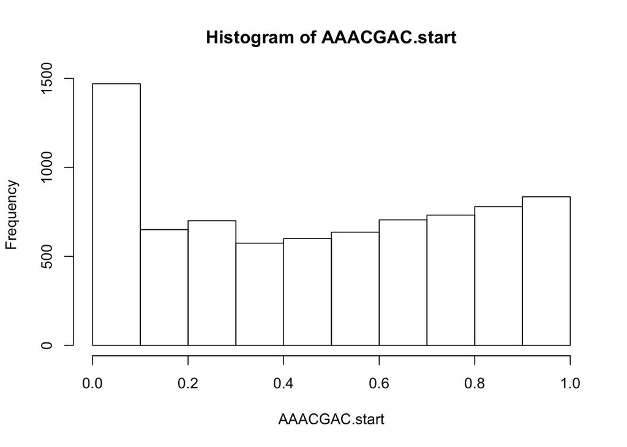

```r
AAACGAC.start.end <- read.table("/Users/jullienflynn/Documents/AndyLab/Heterochromatin/PacBio_scripts/Revised_scripts/D_virilis_satellites_analysis/TEs_satellites/ForR/virilis.all.AAACGAC.start.end")
AAACGAC.start <- as.vector(AAACGAC.start.end$V1)
AAACGAC.end <- as.vector(AAACGAC.start.end$V2)
hist(AAACGAC.start)
```

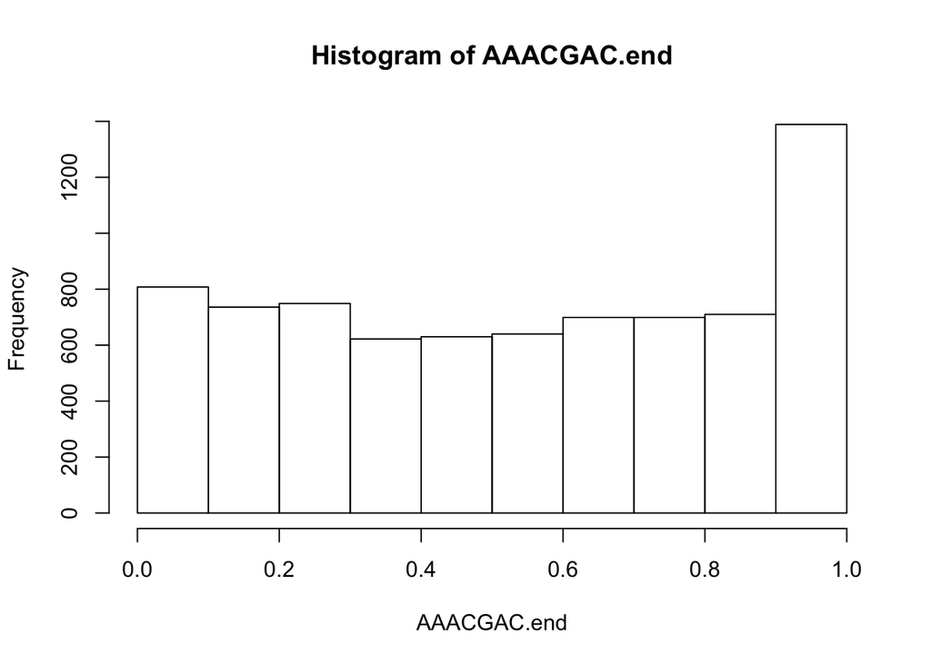

```r
hist(AAACGAC.end)
```

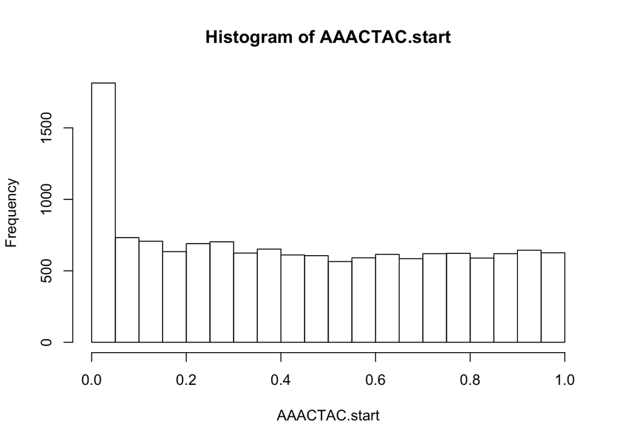

```r
# want to select the ones and see the length here

AAACTAC.start.end <- read.table("/Users/jullienflynn/Documents/AndyLab/Heterochromatin/PacBio_scripts/Revised_scripts/D_virilis_satellites_analysis/TEs_satellites/ForR/virilis.all.AAACTAC.start.end")
AAACTAC.start <- as.vector(AAACTAC.start.end$V1)
AAACTAC.end <- as.vector(AAACTAC.start.end$V2)
hist(AAACTAC.start)
```

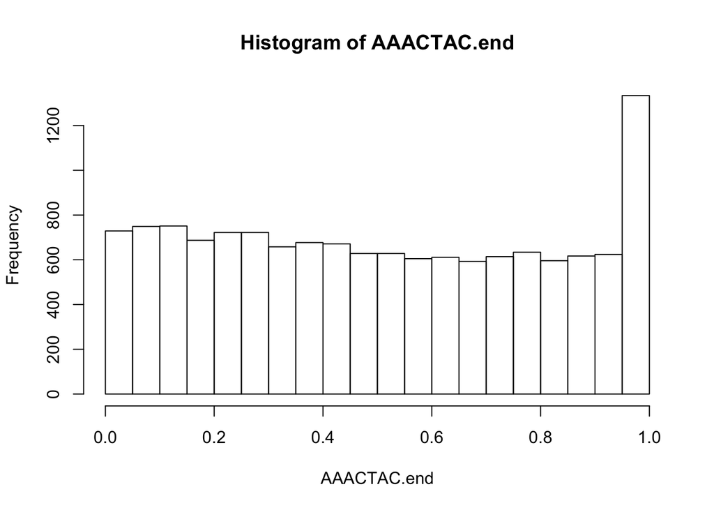

```r
hist(AAACTAC.end)
```

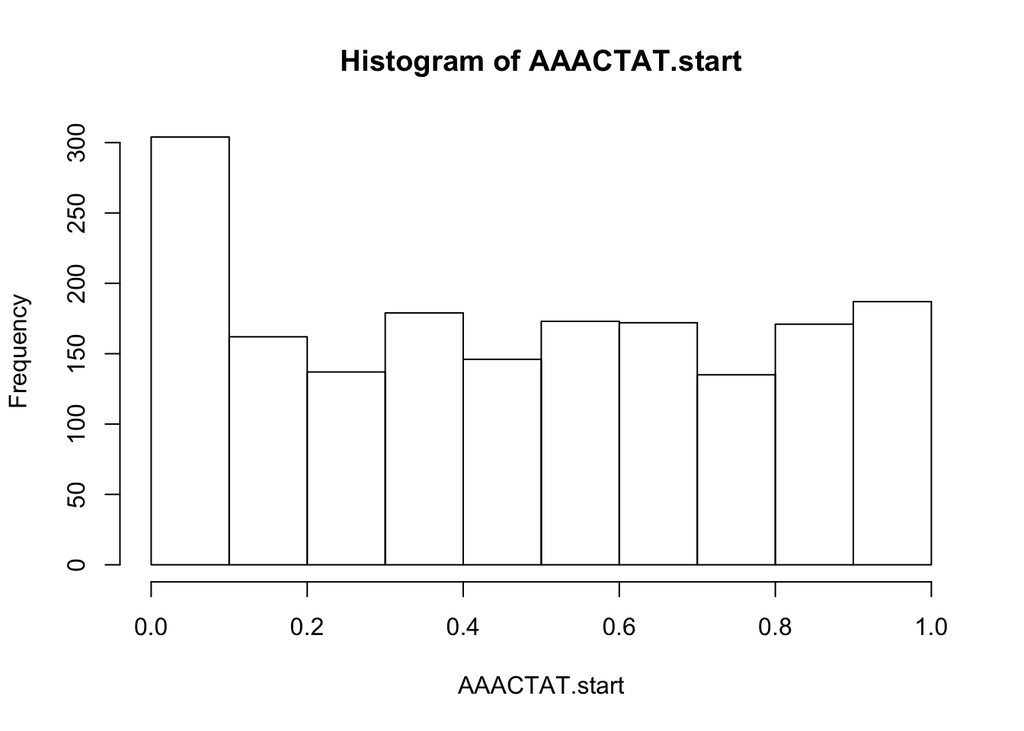

```r
AAACTAT.start.end <- read.table("/Users/jullienflynn/Documents/AndyLab/Heterochromatin/PacBio_scripts/Revised_scripts/D_virilis_satellites_analysis/TEs_satellites/ForR/virilis.all.AAACTAT.start.end")
AAACTAT.start <- as.vector(AAACTAT.start.end$V1)
AAACTAT.end <- as.vector(AAACTAT.start.end$V2)
hist(AAACTAT.start)
```

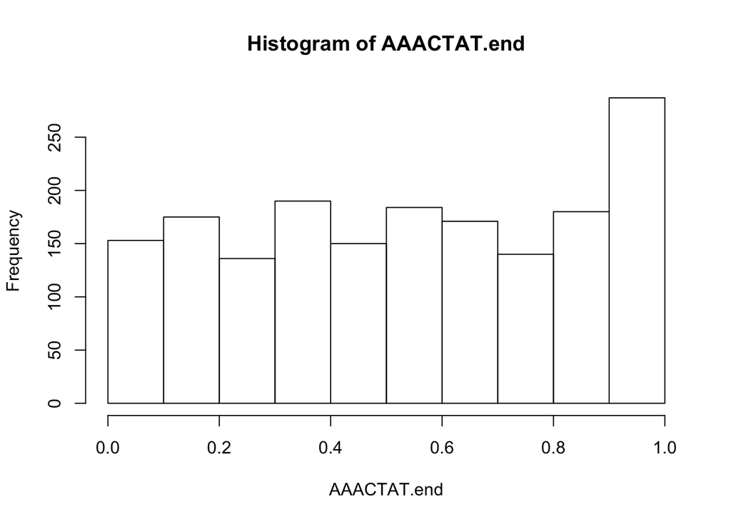

```r
hist(AAACTAT.end)
```

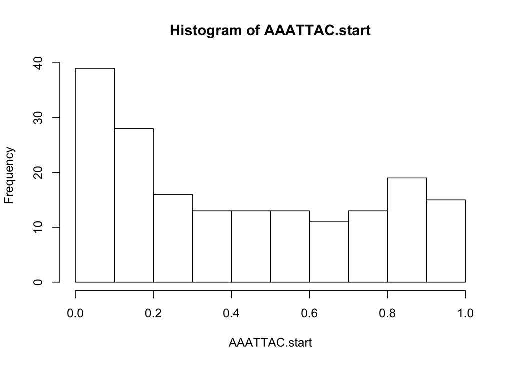

```r
AAATTAC.start.end <- read.table("/Users/jullienflynn/Documents/AndyLab/Heterochromatin/PacBio_scripts/Revised_scripts/D_virilis_satellites_analysis/TEs_satellites/ForR/virilis.all.AAATTAC.start.end")
AAATTAC.start <- as.vector(AAATTAC.start.end$V1)
AAATTAC.end <- as.vector(AAATTAC.start.end$V2)
hist(AAATTAC.start)
```

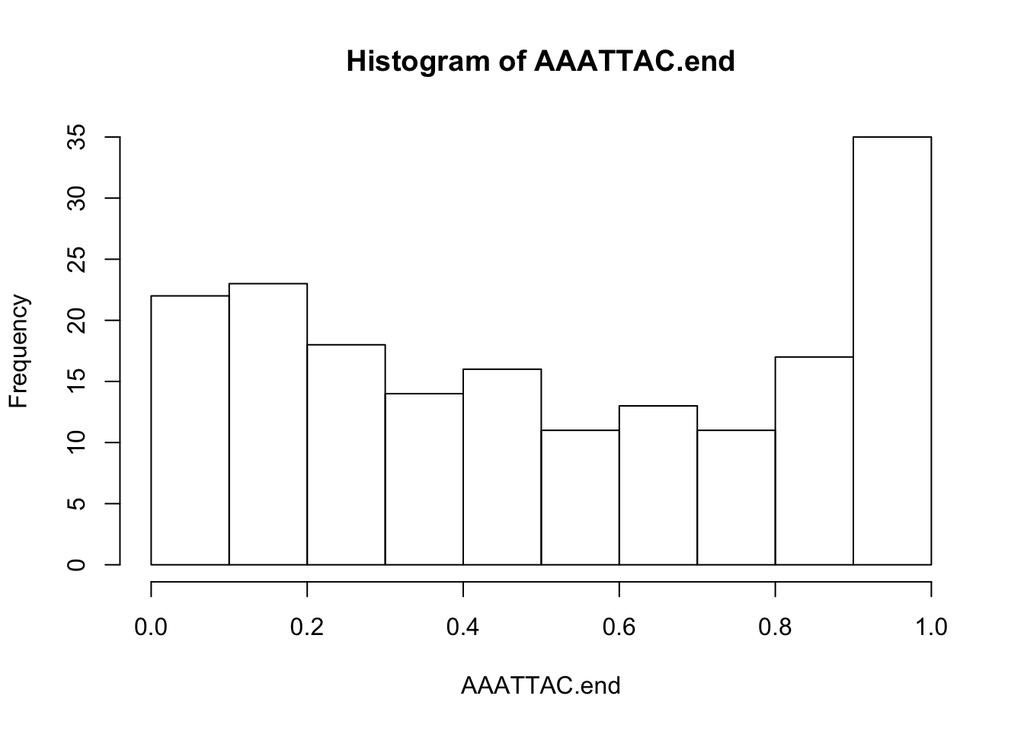

```r
hist(AAATTAC.end)
```